# OB sniff-locked gamma — ridge & phase-continuity analysis (V2)

cueTask (hit/cr), threshTask (air/low/med), O15 (start/free/confirm); bestMac (OB); Dupi split by session (S1/S2/S3) vs OBE

2026-07-01

# Question & data

In OB sniff-locked single-trial gamma, the sniff drives a power increase whose instantaneous frequency **descends** (a downchirp). Is this **one oscillator sweeping down**, or **two fixed oscillators** whose sum only *looks* like a chirp? We test the decidable form: during the transition, is there one moving spectral component or two simultaneously-present ones?

**Data:** preprocessed finals (`fs = 500 Hz`), OB channel `outDat.bestMac`, epoched on `behDat.finalOnset` (−1 to +3 s, padded ±1.5 s), noise-rejected on bestMac (`cue_noise_trials`, K=10). **Tasks & trial types this round:** **cueTask** split into `type=='hit'` vs `type=='cr'`; **O15** split into `sniffLabel ∈ {start, free, confirm}` (each epoch truncated at the next sniff — `burstTruncated` flag); **threshTask** split into `type ∈ {air, low, med}` (added once bestMac was selected). Groups: **Dupi split by session — DupiS1 / DupiS2 / DupiS3** (the trailing visit number) — vs **OBE** (controls, one group).

**Pipeline:** FASLT TFR (20–70 Hz) → per-frequency baseline z-score (−1000..−500 ms) → primary ridge (`tfridge`) + Gaussian-FWHM peel → secondary ridge. Continuity measures: `gammaPeak*`; `peakBurst*` (z-power at the peak frequency ≥2) vs `ridgeBurst*` (smoothed ridge power ≥2); `peakPhaseConsistency` (vs constant-freq reference) vs `ridgePhaseConsistency` (vs accumulated ridge-frequency, i.e. the single-oscillator hypothesis); peak-aligned mean TFR. All measures are averaged **separately per trial-type category**. Statistics (below) are computed in R from the same per-subject CSVs that feed the figures, so numeric values and figures are consistent.

Per-session summary (cueTask; note: pre-category)

| session | bestMac | nTrials | retention | fracHasPeak | medGammaPeakFreq | medGammaPeakTime | medPeakBurstLen | medRidgeBurstLen | medPeakPhaseWideWin | medRidgePhaseWideWin |
| --- | --- | --- | --- | --- | --- | --- | --- | --- | --- | --- |
| 250623_Dupi_NMH_KS_1 | macBP2 | 40 | 0.90 | 1 | 42.0 | 278 | 582 | 2246 | 855 | 830 |
| 250623_Dupi_NMH_KS_2 | macBP3 | 40 | 1.00 | 1 | 43.5 | 303 | 490 | 1886 | 771 | 781 |
| 250623_Dupi_NMH_KS_3 | macBP2 | 40 | 0.95 | 1 | 48.0 | 353 | 452 | 1815 | 760 | 666 |
| 250811_Dupi_NMH_TB_2 | macBP2 | 37 | 0.95 | 1 | 46.0 | 370 | 466 | 2282 | 872 | 792 |
| 250811_Dupi_NMH_TB_3 | macBP1 | 32 | 0.97 | 1 | 52.0 | 386 | 646 | 2928 | 844 | 978 |
| 250811_Dupi_NMH_TPB_1 | macBP1 | 38 | 0.87 | 1 | 47.0 | 284 | 602 | 2354 | 808 | 1060 |
| 250818_Dupi_NMH_JH_1 | macBP2 | 40 | 0.98 | 1 | 51.0 | 270 | 530 | 2242 | 748 | 690 |
| 250818_Dupi_NMH_JH_2 | macBP1 | 37 | 0.22 | 1 | 36.5 | 448 | 587 | 2271 | 908 | 709 |
| 250818_Dupi_NMH_JH_3 | macBP4 | 39 | 1.00 | 1 | 46.0 | 296 | 502 | 2510 | 736 | 1006 |
| 250929_Dupi_NMH_GH_1 | macBP3 | 38 | 1.00 | 1 | 43.5 | 374 | 433 | 1559 | 895 | 815 |
| 250929_Dupi_NMH_GH_2 | macBP3 | 40 | 0.92 | 1 | 45.0 | 322 | 448 | 1614 | 844 | 618 |
| 250929_Dupi_NMH_GH_3 | macBP3 | 40 | 0.92 | 1 | 42.0 | 260 | 410 | 1052 | 838 | 1004 |
| 251002_Dupi_NMH_AB_1 | macBP2 | 39 | 0.92 | 1 | 45.0 | 348 | 520 | 2043 | 892 | 791 |
| 251002_Dupi_NMH_AB_2 | macBP2 | 39 | 0.90 | 1 | 40.0 | 256 | 458 | 3384 | 748 | 712 |
| 251002_Dupi_NMH_AB_3 | macBP1 | 39 | 0.59 | 1 | 39.0 | 462 | 744 | 3226 | 712 | 866 |
| 251013_Dupi_NMH_JN_2 | macBP2 | 40 | 0.98 | 1 | 52.0 | 142 | 490 | 1584 | 850 | 850 |
| 251013_Dupi_NMH_JN_3 | macBP5 | 40 | 0.98 | 1 | 44.0 | 314 | 490 | 4000 | 776 | 1036 |
| 251027_Dupi_NMH_DL_1 | macBP2 | 39 | 1.00 | 1 | 44.0 | 460 | 488 | 2192 | 886 | 724 |
| 251030_Dupi_NMH_DB_1 | macBP1 | 38 | 0.95 | 1 | 46.5 | 314 | 448 | 2181 | 772 | 772 |
| 251030_Dupi_NMH_DB_2 | macBP2 | 37 | 1.00 | 1 | 40.0 | 482 | 496 | 3114 | 790 | 956 |
| 251110_Dupi_NMH_PC_1 | macBP1 | 36 | 0.97 | 1 | 38.0 | 380 | 496 | 1814 | 792 | 882 |
| 251110_Dupi_NMH_PC_2 | macBP1 | 39 | 0.85 | 1 | 37.0 | 410 | 598 | 3108 | 766 | 894 |
| 251120_Dupi_NMH_JL_1 | macBP1 | 40 | 1.00 | 1 | 45.5 | 319 | 463 | 1965 | 879 | 829 |
| 251120_Dupi_NMH_JL_2 | macBP1 | 39 | 1.00 | 1 | 45.0 | 354 | 488 | 1844 | 800 | 704 |
| 260316_Dupi_NMH_PD_1 | macBP3 | 40 | 0.75 | 1 | 51.0 | 240 | 783 | 3412 | 1063 | 840 |
| 260406_Dupi_NMH_BS_1 | macBP5 | 40 | 0.55 | 1 | 46.0 | 501 | 616 | 2762 | 828 | 831 |
| 260406_Dupi_NMH_BS_2 | macBP4 | 40 | 0.45 | 1 | 38.0 | 157 | 444 | 931 | 647 | 458 |
| 260504_Dupi_NMH_JA_1 | macBP3 | 40 | 0.98 | 1 | 46.0 | 358 | 578 | 2348 | 784 | 898 |
| 230611_OBE_NMH_AZ | macBP3 | 40 | 0.78 | 1 | 47.0 | 372 | 448 | 3014 | 748 | 820 |
| 240923_OBE_NMH_HRM | macBP2 | 40 | 1.00 | 1 | 37.5 | 278 | 511 | 3040 | 864 | 874 |
| 241017_OBE_NMH_AS | macBP2 | 40 | 1.00 | 1 | 50.5 | 312 | 623 | 3736 | 751 | 766 |
| 250310_OBE_NMH_FS | macBP1 | 40 | 1.00 | 1 | 46.0 | 356 | 685 | 2701 | 840 | 726 |
| 250313_OBE_NMH_CS | macBP4 | 39 | 1.00 | 1 | 49.0 | 400 | 666 | 4000 | 730 | 678 |
| 260326_OBE_NWU_AD_2 | macBP3 | 60 | 0.93 | 1 | 44.0 | 416 | 550 | 3592 | 752 | 903 |
| 260514_OBE_NWU_BW_1 | macBP2 | 40 | 0.90 | 1 | 40.0 | 453 | 767 | 4000 | 875 | 946 |

# Task: cueTask

## cueTask — hit

### Group mean TFR & peak-aligned TFR

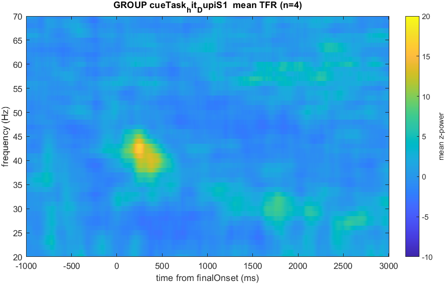

DupiS1 hit mean TFR

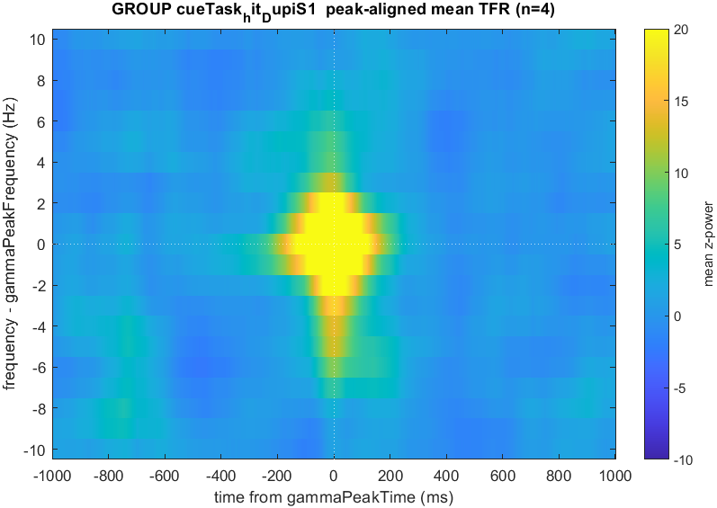

DupiS1 hit peak-aligned

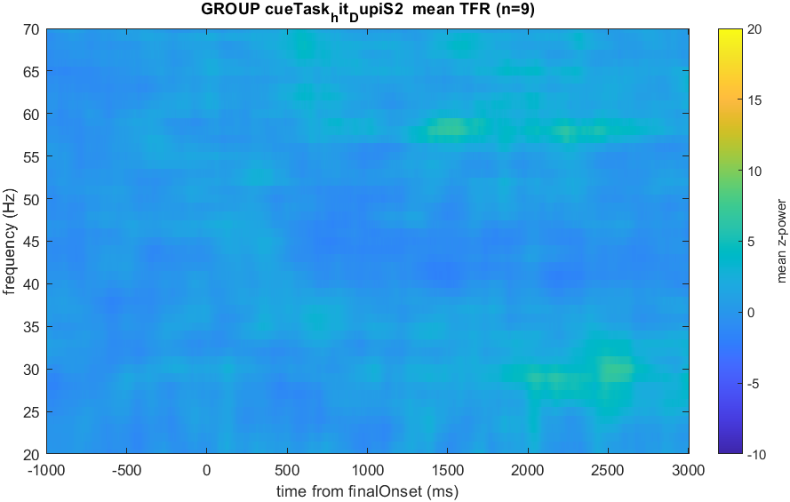

DupiS2 hit mean TFR

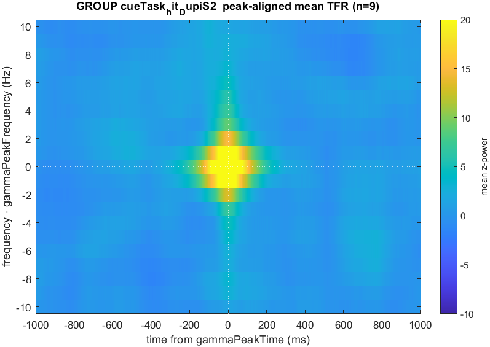

DupiS2 hit peak-aligned

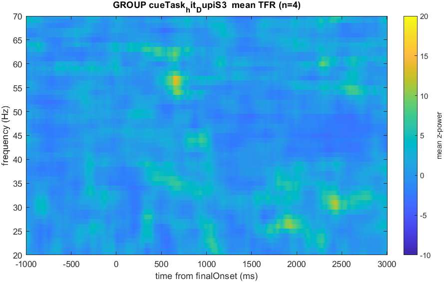

DupiS3 hit mean TFR

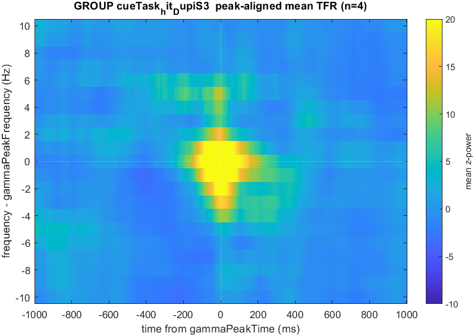

DupiS3 hit peak-aligned

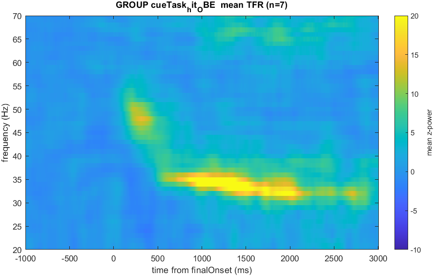

OBE hit mean TFR

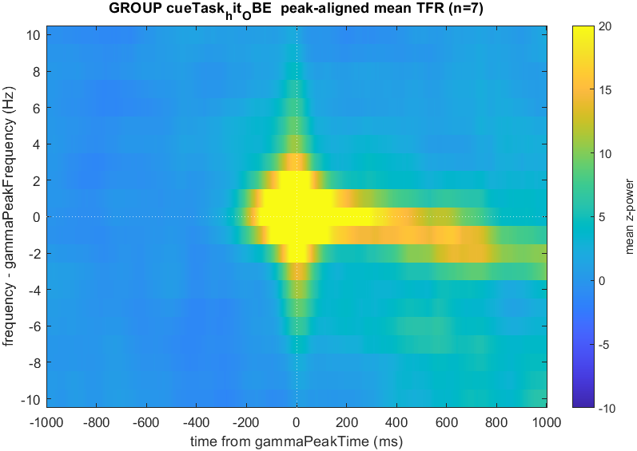

OBE hit peak-aligned

### Single-trial examples (TFR + primary/secondary ridge)

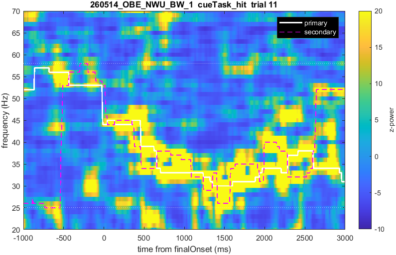

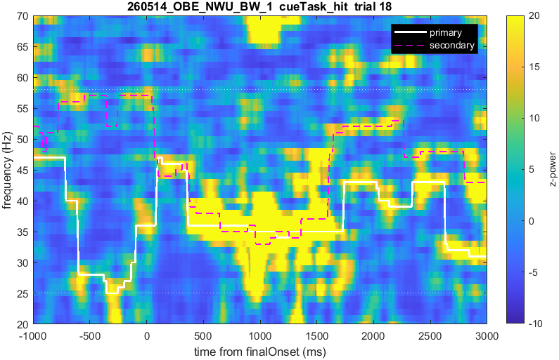

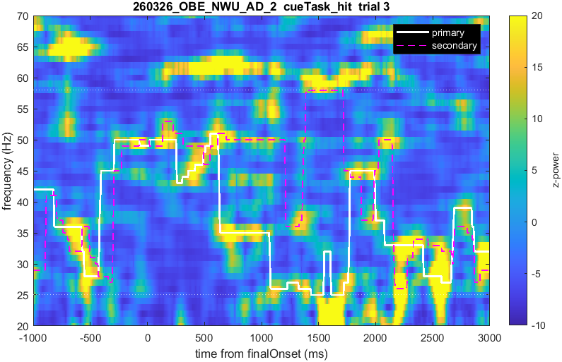

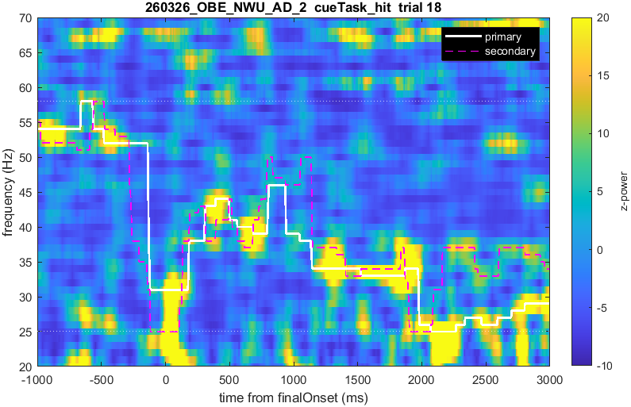

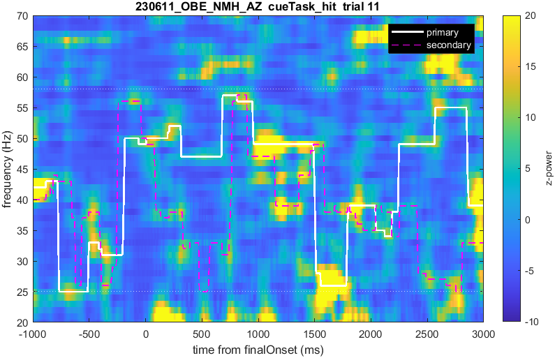

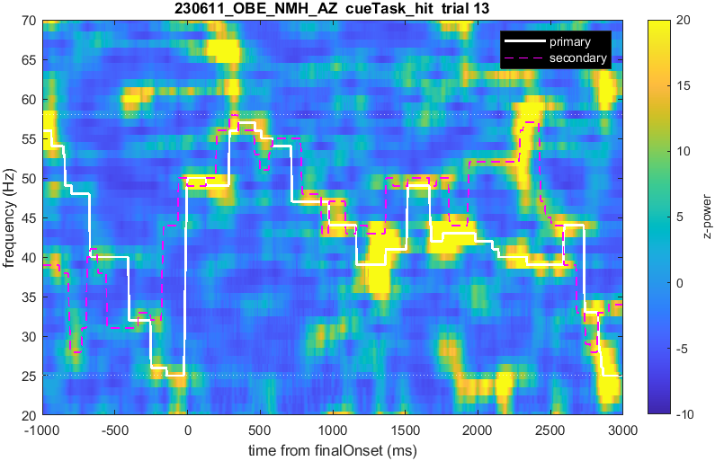

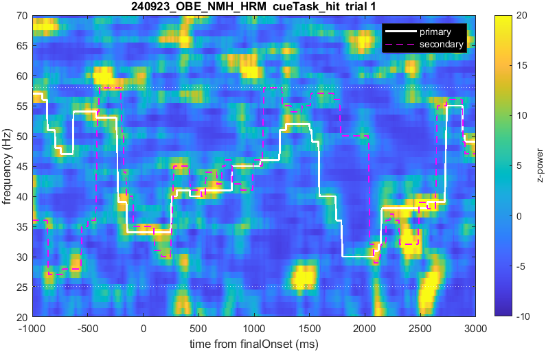

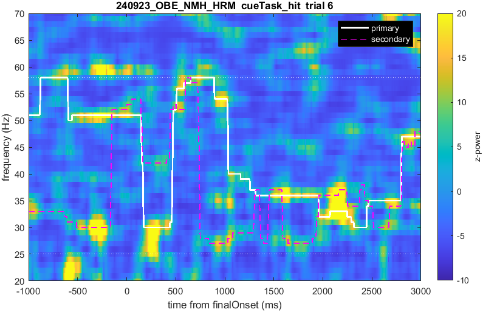

### Phase continuity (peak vs ridge)

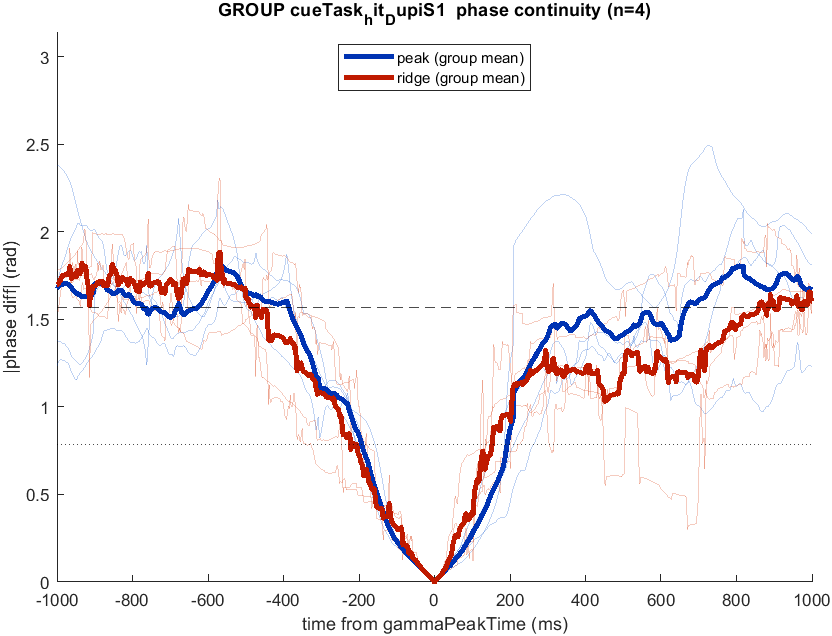

DupiS1 group

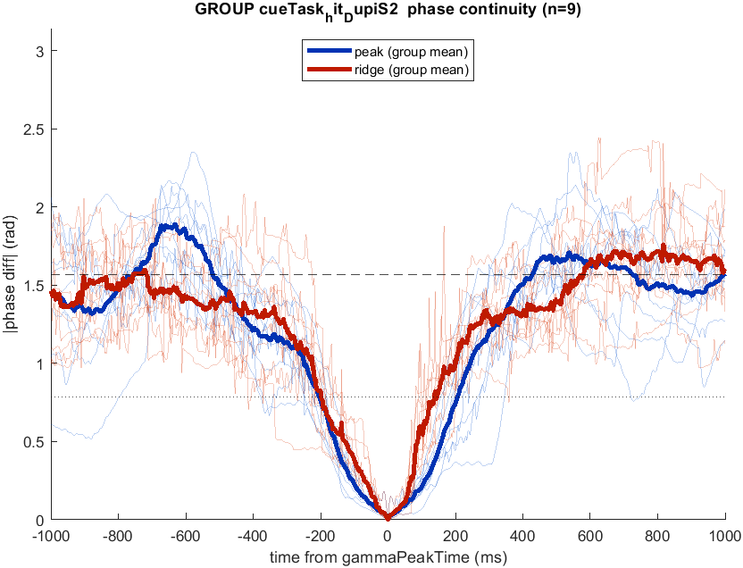

DupiS2 group

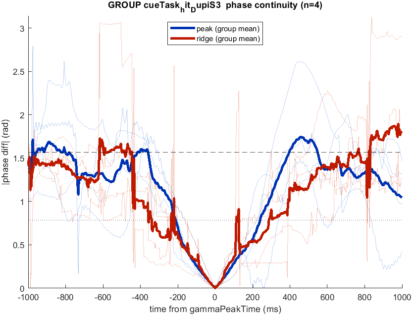

DupiS3 group

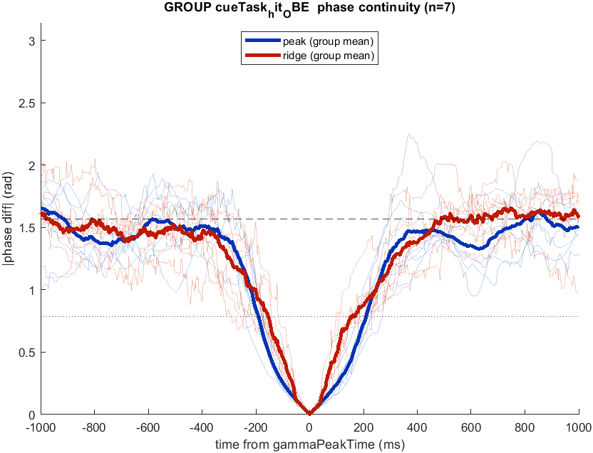

OBE group

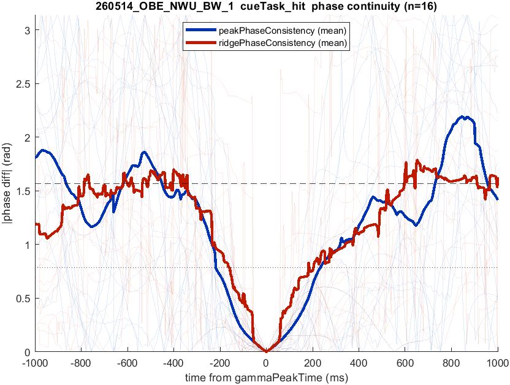

260514_OBE_NWU_BW_1

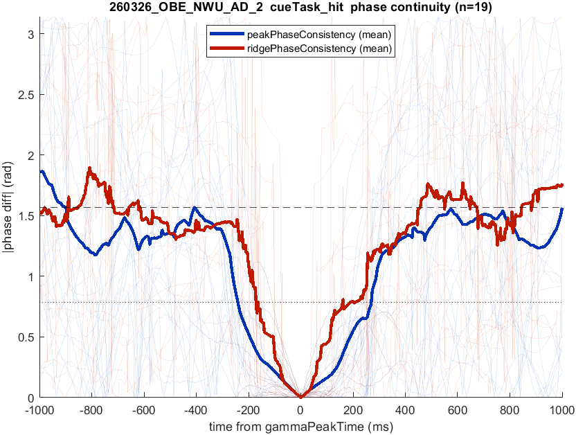

260326_OBE_NWU_AD_2

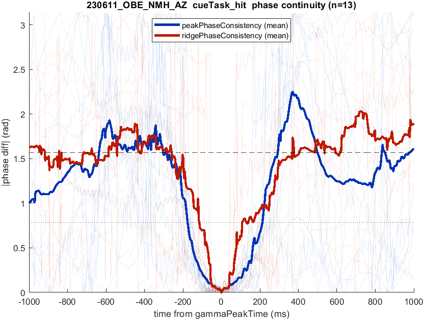

230611_OBE_NMH_AZ

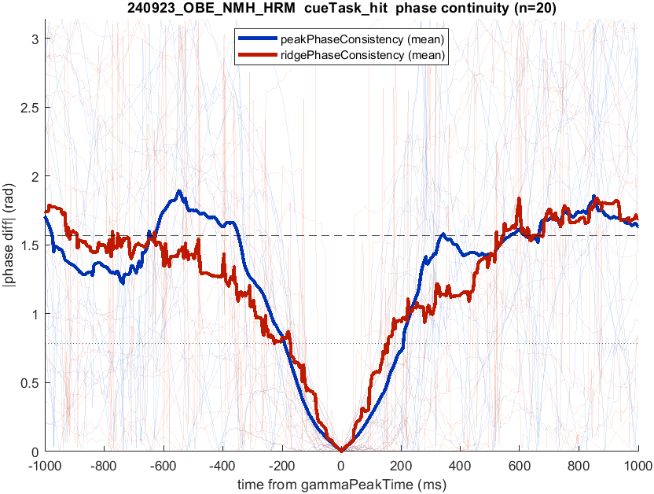

240923_OBE_NMH_HRM

- **DupiS1** (n=4 subj): no timepoints survive correction.
- **DupiS2** (n=9 subj): peak vs ridge |phase diff| differ (max-stat perm, corrected p<0.05) at 9 timepoints, -706 to 160 ms.
- **DupiS3** (n=4 subj): no timepoints survive correction.
- **OBE** (n=7 subj): peak vs ridge |phase diff| differ (max-stat perm, corrected p<0.05) at 7 timepoints, 116 to 148 ms.

### Burst length (peak vs ridge)

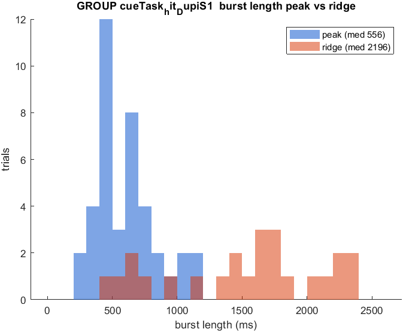

DupiS1 group

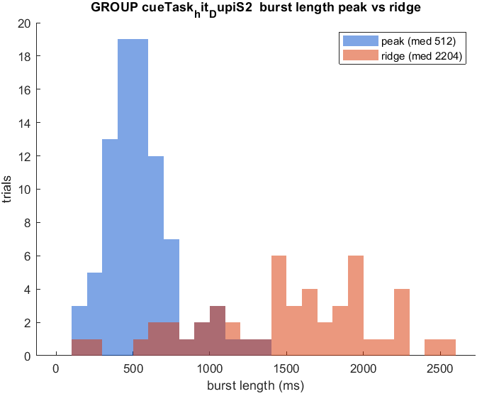

DupiS2 group

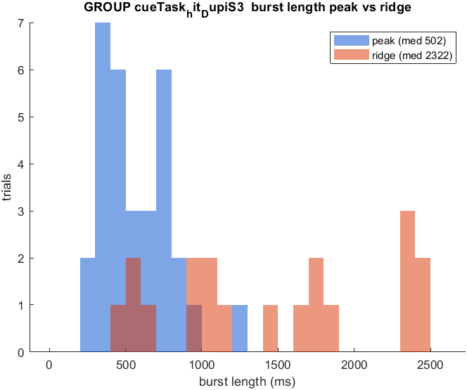

DupiS3 group

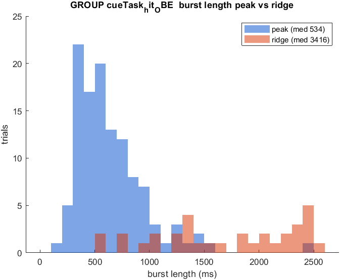

OBE group

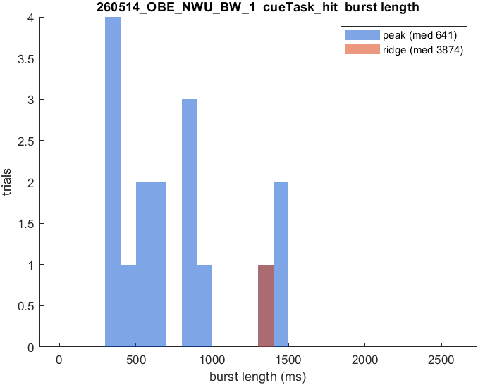

260514_OBE_NWU_BW_1

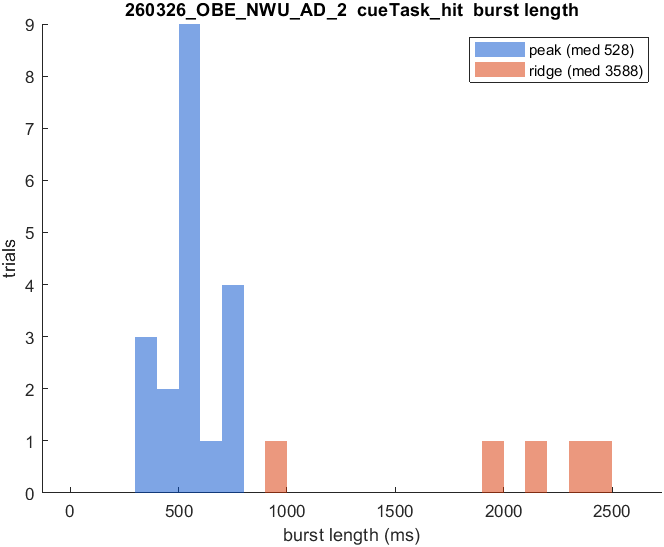

260326_OBE_NWU_AD_2

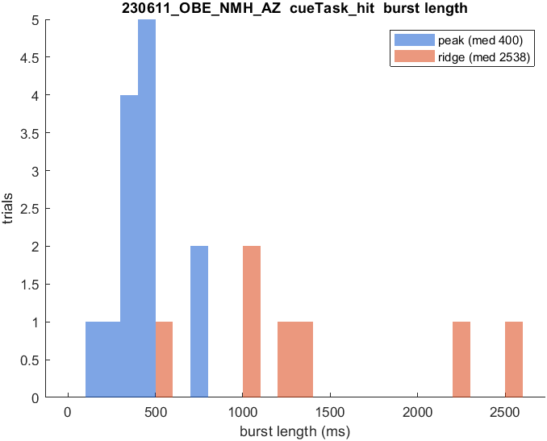

230611_OBE_NMH_AZ

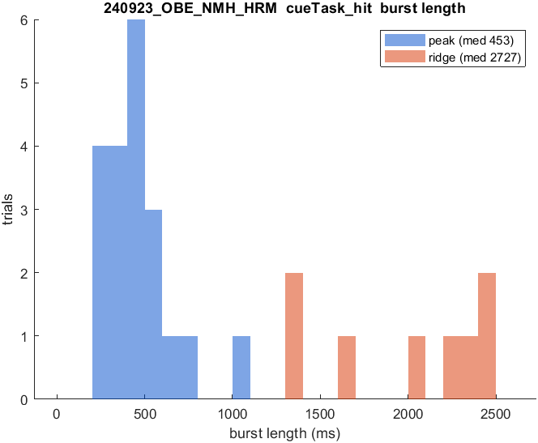

240923_OBE_NMH_HRM

- **DupiS1** (n=4): median peak 583 ms vs ridge 1898 ms; paired Wilcoxon p=0.125 (ridge−peak median diff 1316 ms).
- **DupiS2** (n=9): median peak 504 ms vs ridge 2271 ms; paired Wilcoxon p=0.003906 (ridge−peak median diff 1721 ms).
- **DupiS3** (n=4): median peak 632 ms vs ridge 1892 ms; paired Wilcoxon p=0.125 (ridge−peak median diff 1436 ms).
- **OBE** (n=7): median peak 641 ms vs ridge 3484 ms; paired Wilcoxon p=0.01563 (ridge−peak median diff 2824 ms).